# A classification system to detect questionable information

Pedro Mota

Tatiana Araújo

# Introduction

From a data set comprised of 18k tweets about the last U.S. Presidential election, which were retrieved before the election was held, labeled as questionable or not, the goal of this project was to create a classification system for tweets in order to identify where a new (unseen) tweet is disseminating questionable information, or not. Despite the simple problem statement, it is a hard task because natural language is full of ambiguities and imprecise characteristics, therefore making it impossible for a human to devise, manually, a set of rules to determine if a tweet contains questionable information or not. With this in mind, we tried to tackle this problem by exploiting, for the questionable and non-questionable tweets, the different vocabulary used (which can be captured by a term frequency analysis), the different sentiment and emotion distribution and, also, the conflicting valence found in the tweets, usually called *emotional entropy*, which can be thought of as a measure of unpredictability and surprise based on the consistency or inconsistency of the emotional language in a given message and used this information in machine learning algorithms.

For all the analysis, we used the language R and some of its packages from the CRAN, which we will load now:

```r
library(tidyverse)
library(dlookr)
library(cowplot)
library(tm)
library(text2vec)
library(ggplot2)
library(wordcloud)
library(superml)
library(Hmisc)
library(syuzhet)
library(caret)
library(reshape2)
library("ggpubr")
library(DMwR)
```

## Data importation

We will start, by reading the .csv file, containing the data, as a tibble.

```r
ds <- as_tibble(read_csv("FN-Dataset-18k.csv"))
```

A first glimpse of the data:

```r
glimpse(ds)
```

```
## Rows: 17,950
## Columns: 11
## $ id                    <dbl> 1.310325e+18, 1.310896e+18, 1.311657e+18, 1.3123…
## $ questionable_domain   <lgl> FALSE, TRUE, FALSE, FALSE, FALSE, FALSE, FALSE, …
## $ user_friends_count    <dbl> 3822, 4378, 29, 400, 98, 400, 1003, 857, 411, 65…
## $ user_followers_count  <dbl> 1084, 30443, 43, 4857, 825, 445, 372, 5164, 70, …
## $ user_favourites_count <dbl> 49451, 113064, 0, 1942, 2848, 987, 6487, 1562, 1…
## $ user_verified         <lgl> FALSE, FALSE, FALSE, FALSE, FALSE, FALSE, FALSE,…
## $ description           <chr> "Glad to hear that the @SenateDems, @HouseDemocr…
## $ title                 <chr> "Glad to hear that the @SenateDems, @HouseDemocr…
## $ favorite_count        <dbl> 0, 56, 0, 2, 0, 0, 0, 0, 0, 0, 1, 0, 0, 0, 0, 0,…
## $ retweet_count         <dbl> 0, 26, 0, 0, 0, 0, 0, 0, 0, 0, 0, 0, 0, 0, 0, 0,…
## $ contains_profanity    <lgl> FALSE, FALSE, FALSE, FALSE, FALSE, FALSE, FALSE,…
```

One can see that, the columns ending with *count* are wrongly typed, ie., they are typed as doubles, but they are integer values. Also, we converted the **user_verified** and **contains_profanity** from logical to 0/1 integer values and the target variable **questionable_domain** from a logical value to a factor:

```r
ds <- mutate(ds,
            user_friends_count = as.integer(user_friends_count),
            user_followers_count = as.integer(user_followers_count),
            user_favourites_count = as.integer(user_favourites_count),
            retweet_count = as.integer(retweet_count),
            favorite_count = as.integer(favorite_count),
            user_verified = as.integer(user_verified),
            contains_profanity = as.integer(contains_profanity),
            questionable_domain = as.factor(questionable_domain)
)
```

Other thing that we noticed is that the attribute *title* is redundant. Firstly, there are only 13 cases where the attribute *title* is different than the attribute *description*:

```r
sum(as.integer(ds$title != ds$description))
```

```
## [1] 13
```

And, in those cases (and also in the ones where they are exactly equal), the attribute *title* is a prefix of the *description* attribute.

```r
all(startsWith(ds$description, ds$title))
```

```
## [1] TRUE
```

So, we can remove the *title* field.

```r
ds <- select(ds, -title)
```

Let’s now look for missing values and duplicate observations, which can compromise our analysis. For that, we will use the package *dlookr*:

```r
overview(ds)
```

```
##      division               metrics   value
## 1        size          observations   17950
## 2        size             variables      10
## 3        size                values  179500
## 4        size           memory size 5957704
## 5  duplicated duplicate observation       0
## 6     missing  complete observation   17950
## 7     missing   missing observation       0
## 8     missing     missing variables       0
## 9     missing        missing values       0
## 10  data type              numerics       1
## 11  data type              integers       7
## 12  data type       factors/ordered       1
## 13  data type            characters       1
## 14  data type                 Dates       0
## 15  data type              POSIXcts       0
## 16  data type                others       0
```

As we can see, there is no missing values, neither duplicates in our data set.

Regarding outliers, we concluded that we don’t have any of them. Mainly, because the data collection was autonomously done and it doesn’t suffer from reading problems, such as sensor data. Also, we inspected the range of the values for these attributes and they all seem plausible, as we can see:

```r
min_num_cols = apply(select(ds, ends_with("count")), 2, min)
max_num_cols = apply(select(ds, ends_with("count")), 2, max)

df <- data.frame(min_num_cols, max_num_cols)
colnames(df) <- c('Min' , 'Max')
df[-1,]
```

```
##                       Min      Max
## user_followers_count    0 48140763
## user_favourites_count   0   909295
## favorite_count          0    13180
## retweet_count           0    12858
```

## Baseline Model

Before we further process and analyse our data, let’s create a simple baseline model.

Prior to the baseline model, let’s split our data set in two independent data sets, one in which we will perform our analysis and train our models and other set, which we will never use, until the very end, where we will do a final prediction on unseen data:

```r
inTrain <- createDataPartition(y = ds$questionable_domain, p = 0.85, list = FALSE)
ds_train <- ds %>% dplyr::slice(inTrain)
ds_test <- ds %>% dplyr::slice(-inTrain)
```

Let’s just make sure that the distribution of the data between the training set and testing set are similar.

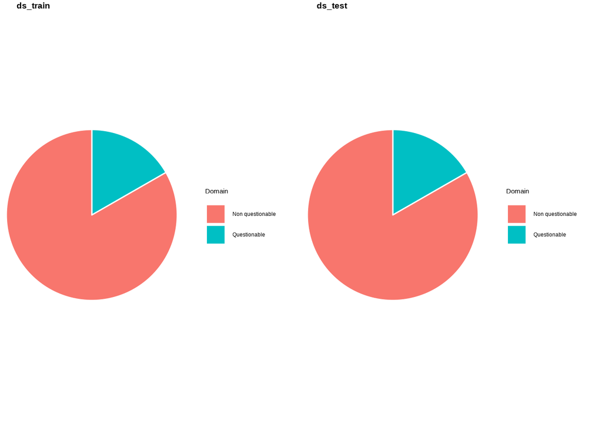

```r
piechart_dist <- function(ds) {
  data <- data.frame(
    Domain=c('Questionable', 'Non questionable'),
    value=c(nrow(filter(ds, questionable_domain==T)),  nrow(filter(ds, questionable_domain==F)))
  )

  data <- data %>%
    arrange(desc(Domain)) %>%
    mutate(prop = value / sum(data$value) *100) %>%
    mutate(ypos = cumsum(prop)- 0.5*prop )

  plot <- ggplot(data, aes(x="", y=value, fill=Domain)) +
    geom_bar(stat="identity", width=1, color="white") +
    coord_polar("y", start=0) +
    theme_void()
  plot
}

plot_grid(piechart_dist(ds_train), piechart_dist(ds_test), labels = c("ds_train", "ds_test"), scale=1.1)
```

As we can see, both follow the same distribution as required.

For the baseline model, we could create one model that simply outputs that the tweet is non-questionable. Since, in the whole data set, we have 3000 questionable tweets and, therefore, 14950 non-questionable tweets, we would get an accuracy around 83%, a precision of 100% but a recall of 0%.

Instead of this, we decided to use five models (with variations): - k-Nearest Neighbors (with k equals to 5, 8, 11 and 14) - Naive Bayes (with Laplace correction of 1) - XGBoost (using 50, 100, 150 and 200 iterations)  
- Random Forests (with 300 trees) - Neural Networks (we used only one hidden layer and varied the number of neurons for the hidden layer from 1 to the number of attributes)

Now, let’s build a pipeline. We will estimate the *accuracy*, the *precision*, the *recall* and the *F1 measure*, using the 10-fold cross validation method:

```r
fit <- function(x_train, y_train, x_test, y_test) {
    results <- tibble()

    # 10-fold Cross Validation
    control = trainControl(method  = "cv", number  = 10, classProbs = F)

    # k-NN
    cat("k-NN... ")
    knn_model <- train(x = x_train,
                       y = y_train,
                       method     = "knn",
                       tuneGrid   = expand.grid(k = seq(from=5, to=15, by=3)),
                       trControl  = control)
    knn_results <- predict(knn_model, x_test)
    knn_conf <- confusionMatrix(knn_results, y_test)
    results <- rbind(results, c(knn_conf$overall["Accuracy"], knn_conf$byClass["Precision"], knn_conf$byClass["Recall"], knn_conf$byClass["F1"]))
    cat("DONE\n")

    # NAIVE BAYES
    cat("Naive Bayes... ")
    nb_model = train(x = x_train,
                     y = y_train,
                     method = 'naive_bayes',
                     trControl = control,
                     tuneGrid = data.frame(usekernel = TRUE, laplace = 1, adjust = 1))
    nb_results <- predict(nb_model, x_test)
    nb_conf <- confusionMatrix(nb_results, y_test)
    results <- rbind(results, c(nb_conf$overall["Accuracy"], nb_conf$byClass["Precision"], nb_conf$byClass["Recall"], nb_conf$byClass["F1"]))
    cat("DONE\n")

    # XGBOOST
    cat("XGBoost... ")
    xgb_model = train(x = x_train,
                      y = y_train,
                      trControl = control,
                      method = "xgbTree",
                      tuneGrid = expand.grid(nrounds = c(50,100,150,200), max_depth = c(2,5), eta = 0.05, gamma = 0.01,
                                      colsample_bytree = c(0.3,0.7), min_child_weight=0, subsample = 0.7),
                      verbosity = 0)
    #varImp(xgb_model)
    xgb_results <- predict(xgb_model, x_test)
    xgb_conf <- confusionMatrix(xgb_results, y_test)
    results <- rbind(results, c(xgb_conf$overall["Accuracy"], xgb_conf$byClass["Precision"], xgb_conf$byClass["Recall"], xgb_conf$byClass["F1"]))
    cat("DONE\n")

    # RANDOM FOREST
    cat("Random Forest... ")
    rf_model <- train(x = x_train,
                      y = y_train,
                      method = "ranger",
                      trControl = control,
                      tuneGrid = expand.grid(.mtry = seq(from=2, to=ceil(ncol(x_train)/2), by=3), .splitrule="gini", .min.node.size = c(2, 5, 10, 20)),
                      num.trees = 300,
                      importance = "impurity")
    #varImp(rf_model)
    rf_results <- predict(rf_model, newdata=x_test)
    rf_conf <- confusionMatrix(rf_results, y_test)
    results <- rbind(results, c(rf_conf$overall["Accuracy"], rf_conf$byClass["Precision"], rf_conf$byClass["Recall"], rf_conf$byClass["F1"]))
    cat("DONE\n")

    # NEURAL NETS
    cat("Neural Net... ")
    nnet_model <- train(x = x_train,
                       y = y_train,
                       method = 'nnet',
                       trControl = control,
                       tuneGrid=expand.grid(size=1:ncol(x_train), decay=c(0.1)),
                       trace=F)
    nnet_results <- predict(nnet_model, x_test)
    nnet_conf <- confusionMatrix(nnet_results, y_test)
    results <- rbind(results, c(nnet_conf$overall["Accuracy"], nnet_conf$byClass["Precision"], nnet_conf$byClass["Recall"], nnet_conf$byClass["F1"]))
    cat("DONE\n")

    colnames(results) <- c("Accuracy", "Precision", "Recall", "F1")
    rownames(results) <- c("kNN", "Naive Bayes", "XGBoost", "Random Forests", "Neural Networks")
    results
}
```

Now let’s train our baseline model:

```r
x_train <- select(ds_train, -c(id, description, questionable_domain))
y_train <- ds_train$questionable_domain
x_test <- select(ds_test, -c(id, description, questionable_domain))
y_test <- ds_test$questionable_domain

baseline.results <- fit(x_train, y_train, x_test, y_test)
```

Let’s check the results that we got:

```r
baseline.results
```

```
##                  Accuracy Precision    Recall        F1
## kNN             0.8380386 0.8586180 0.9643176 0.9084034
## Naive Bayes     0.2986627 0.8612245 0.1882248 0.3089312
## XGBoost         0.8454681 0.8511538 0.9870651 0.9140851
## Random Forests  0.8480684 0.8502102 0.9924175 0.9158263
## Neural Networks 0.8328380 0.8328380 1.0000000 0.9087961
```

## Data exploration and pre-processing

We will now explore the data, by means of summarization and visualization, as to get useful insights. We will also look into the correlation between our variables and also their correlation with the target variable.

Firstly, we will explore how the user activity is related to the questionability of the tweet. The attributes regarding the user activity are: *user_verified*, *user_friends_count*, *user_followers_count* and *user_favourites_count*.

Firstly, regarding the *user_verified* attribute, we expect that verified users don’t post questionable tweets, since they usually represent notable people or organizations, such as government officials.

Let’s try to confirm our guess by computing the % of questionable tweets that posted by verified users and also the:

```r
df <- data.frame(c(nrow(filter(ds_train, user_verified==T, questionable_domain==T)) / nrow(filter(ds_train, questionable_domain==T)) * 100,
           nrow(filter(ds_train, user_verified==F, questionable_domain==T)) / nrow(filter(ds_train, questionable_domain==T)) * 100),
           c(nrow(filter(ds_train, user_verified==T, questionable_domain==F)) / nrow(filter(ds_train, questionable_domain==F)) * 100,
           nrow(filter(ds_train, user_verified==F, questionable_domain==F)) / nrow(filter(ds_train, questionable_domain==F)) * 100))
colnames(df) <- c('Questionable tweet', 'Non questionable')
row.names(df) <- c('Verified user', 'Non verified user')
df
```

```
##                   Questionable tweet Non questionable
## Verified user              0.8627451         6.444759
## Non verified user         99.1372549        93.555241
```

As we can see, the vast majority of verified users post non-questionable tweets, making *user_verified* a relevant attribute.

Regarding the *user_followers_count*, for the same reason as before, we expect to see users with an high number of followers, to not post questionable tweets.

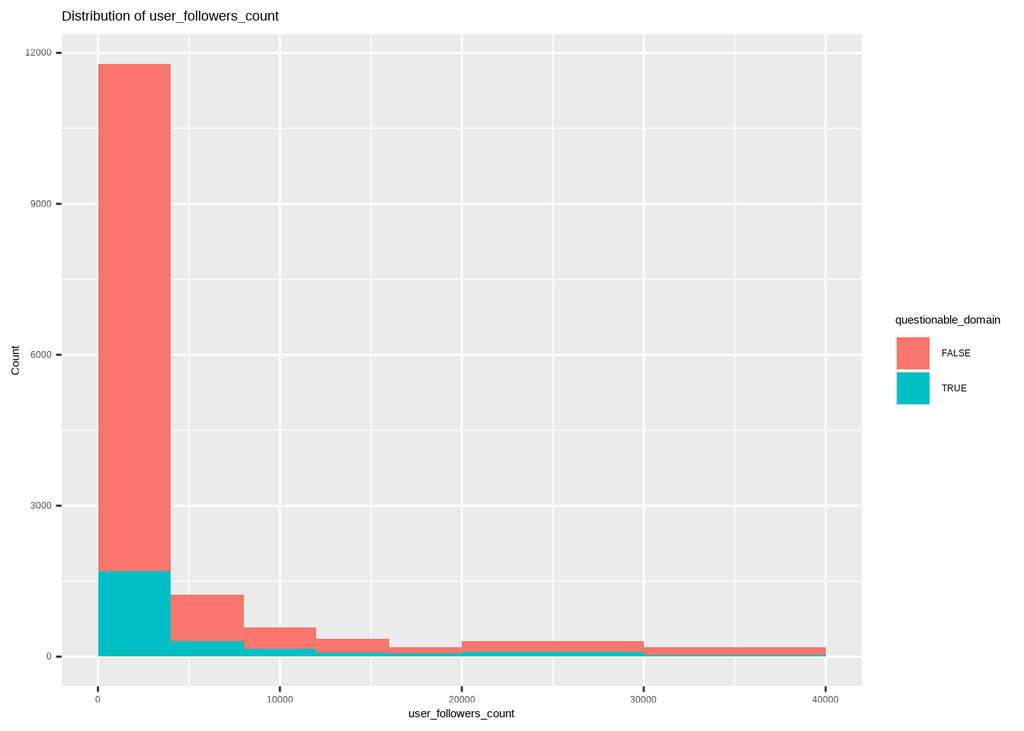

```r
ggplot(ds_train, aes( fill = questionable_domain, x=user_followers_count)) + geom_histogram( breaks=c(0,4000,8000,12000,16000,20000,30000,40000))+ ggtitle("Distribution of user_followers_count ") + ylab("Count")
```

The above plot confirms our guesses.

Regarding the *user_friends_count*, we were more unsure about our intuitions, because an high number of friends means that the user follows an high number of users and so it will be more informed, but it can also mean, for instance, that we are in a presence of a Twitter Bot, which will follow everyone automatically in order to be noticed and spread their message, which may be of a questionable nature.

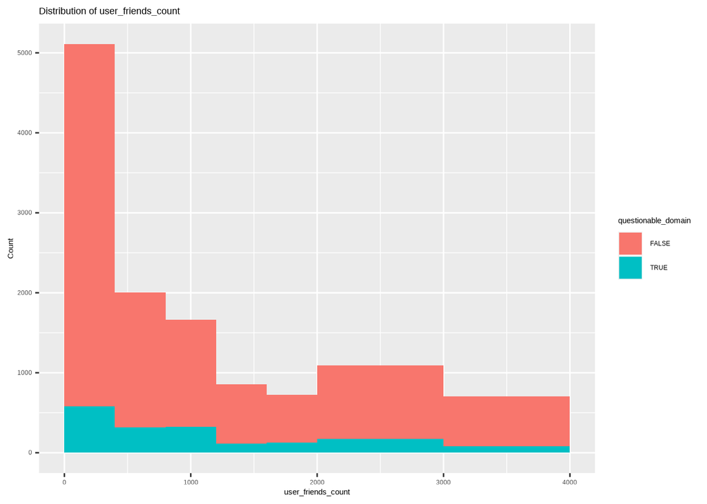

```r
ggplot(ds_train, aes( fill = questionable_domain, x=user_friends_count)) + geom_histogram( breaks=c(0,400,800,1200,1600,2000,3000,4000))+ ggtitle("Distribution of user_friends_count ") + ylab("Count")
```

To our surprise, *user_friends_count* follows roughly the same distribution as the attribute *user_followers_count*.

With respect to *user_favourites_count*, we don’t expect to see any correlation with the target variable, for the same reason as before, but in this case, it’s even harder to make a case for this attribute.

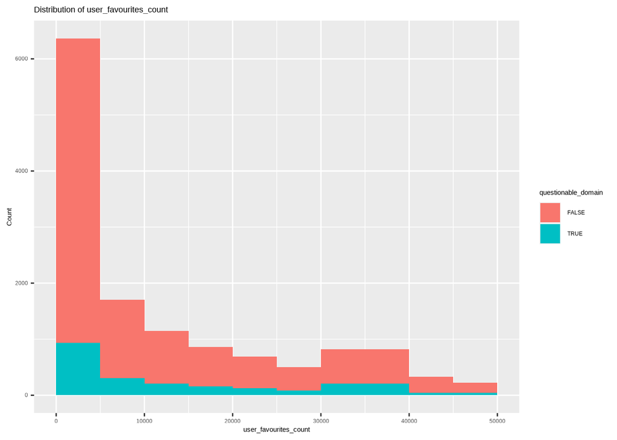

```r
ggplot(ds_train, aes( fill = questionable_domain, x=user_favourites_count)) + geom_histogram( breaks=c(0,5000,10000,15000,20000,25000,30000,40000,45000,50000))+ ggtitle("Distribution of user_favourites_count ") + ylab("Count")
```

Again, to our surprise, *user_favourites_count* follows roughly the same distribution as the attribute *user_followers_count*. All of this attributes, regarding the tweet activity will be important to classify if a tweet is questionable or not.

Now, we will explore how the tweet activity is related to the questionability of the tweet. The attributes regarding the twitter activity are: *favorite_count* and *retweet_count*. We expect to see a negative correlation between the two attributes and the target variable, meaning the higher both of them are, we expect the tweet to be non-questionable, because a tweet with high positive activity - we say ‘positive activity’ because, here, the activity is based on the number of favorites and retweets, which are usually done by the users who agree on the message and not on the number of comments, for instance, which an high amount of them, can mean an high amount of negative comments - therefore meaning that there are a considerable number of people agreeing.

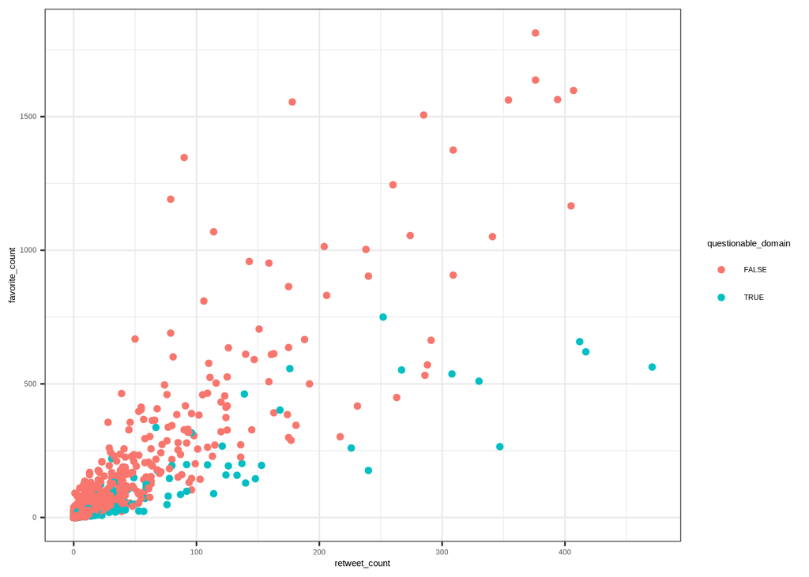

```r
ggplot(data=subset(ds_train, retweet_count<500 & favorite_count<2000), mapping = aes(x = retweet_count, y = favorite_count)) + geom_point(aes(color = questionable_domain)) + theme_bw()
```

As we can see, tweets with an higher engagement tend to not contain questionable information, as we expected.

We will now explore the correlation between all the numeric variables. We expect to see a positive correlation between them, mainly because they are related to either the user or the tweets activity.

```r
res <- cor(select(ds_train, -c(id, description, questionable_domain)), method="spearman")
res
```

```
##                       user_friends_count user_followers_count
## user_friends_count            1.00000000           0.82938283
## user_followers_count          0.82938283           1.00000000
## user_favourites_count         0.54938782           0.48743236
## user_verified                 0.09635487           0.33684900
## favorite_count                0.32300356           0.48292024
## retweet_count                 0.31183382           0.46306289
## contains_profanity           -0.05256858          -0.07597504
##                       user_favourites_count user_verified favorite_count
## user_friends_count               0.54938782    0.09635487     0.32300356
## user_followers_count             0.48743236    0.33684900     0.48292024
## user_favourites_count            1.00000000   -0.04465791     0.20700545
## user_verified                   -0.04465791    1.00000000     0.32867166
## favorite_count                   0.20700545    0.32867166     1.00000000
## retweet_count                    0.17443731    0.32941776     0.69090187
## contains_profanity              -0.01563415   -0.04886222    -0.04588225
##                       retweet_count contains_profanity
## user_friends_count       0.31183382        -0.05256858
## user_followers_count     0.46306289        -0.07597504
## user_favourites_count    0.17443731        -0.01563415
## user_verified            0.32941776        -0.04886222
## favorite_count           0.69090187        -0.04588225
## retweet_count            1.00000000        -0.04991036
## contains_profanity      -0.04991036         1.00000000
```

A bit hard to read. Let’s improve the visualization of the correlation matrix with the function *symmnun* from the package *stats*:

```r
symnum(res, abbr.colnames = F)
```

```
##                       user_friends_count user_followers_count
## user_friends_count    1
## user_followers_count  +                  1
## user_favourites_count .                  .
## user_verified                            .
## favorite_count        .                  .
## retweet_count         .                  .
## contains_profanity
##                       user_favourites_count user_verified favorite_count
## user_friends_count
## user_followers_count
## user_favourites_count 1
## user_verified                               1
## favorite_count                              .             1
## retweet_count                               .             ,
## contains_profanity
##                       retweet_count contains_profanity
## user_friends_count
## user_followers_count
## user_favourites_count
## user_verified
## favorite_count
## retweet_count         1
## contains_profanity                  1
## attr(,"legend")
## [1] 0 ' ' 0.3 '.' 0.6 ',' 0.8 '+' 0.9 '*' 0.95 'B' 1
```

As we can see, we have a lot of correlation between our variables, namely between the ones regarding the user activity and between the ones regarding the tweet activity!

We could simply remove one of the correlated variables, but we decided to perform a principal component analysis in order to remove the correlation between our variables and even reduce the dimensionality of our data set:

```r
ds_train.pca <- prcomp(select(ds_train, -c(id, description, questionable_domain)), center = TRUE, scale. = TRUE)
ds_test.pca <- prcomp(select(ds_test, -c(id, description, questionable_domain)), center = TRUE, scale. = TRUE)

summary(ds_train.pca)
```

```
## Importance of components:
##                           PC1    PC2    PC3    PC4    PC5    PC6    PC7
## Standard deviation     1.3845 1.0799 1.0383 0.9960 0.9257 0.9051 0.4132
## Proportion of Variance 0.2738 0.1666 0.1540 0.1417 0.1224 0.1170 0.0244
## Cumulative Proportion  0.2738 0.4404 0.5944 0.7362 0.8586 0.9756 1.0000
```

From the above matrix, one can see that the first six components already explain almost 98% of the variability of the data. The last principal component only explains roughly 2% of the data. This means if we use the first six principal components, we have one less variable than the 7 original ones and we still maintain roughly 98% of the variability in the data.

With this in mind, we can remove the old numeric attributes and use the new principal components:

```r
ds_train <- select(ds_train, -c(user_verified, user_favourites_count, user_followers_count, user_friends_count,
                    retweet_count, favorite_count, contains_profanity))

ds_train <-cbind(ds_train, ds_train.pca$x[,1:6])

ds_test <- select(ds_test, -c(user_verified, user_favourites_count, user_followers_count, user_friends_count,
                    retweet_count, favorite_count, contains_profanity))

ds_test <-cbind(ds_test, ds_test.pca$x[,1:6])
```

Finally, we will look into the content of the descriptions of the tweets, that is, the field *description*. Let’s first look into a tweet that is questionable and one that is not, respectively:

```r
print(c(filter(ds_train, questionable_domain==T)[1,]$description, filter(ds_train, questionable_domain==F)[1,]$description))
```

```
## [1] "If only those people who swim against the current of freedom and liberty would realize that we were founded as “one nation under God”.   That is what has made our country truly great! #Debates2020 https://t.co/8Ia8YtRYvH"
## [2] "Glad to hear that the @SenateDems, @HouseDemocrats, @SenSchumer &amp; @SpeakerPelosi  will do everything they can to prevent the Supreme Court confirmation.   Fight! Fight! Our health care, our lives, our democracy depend upon it!  https://t.co/qlDYt16FvC"
```

We will now look into the word cloud of the tweets regarding the questionable tweets and the non-questionables, respectively. In a word cloud, the size of the texts in the image represent the frequency or importance of the words in the training data.

Let’s first create the corpus and clean-up the text, by convert all letters to lower case, removing numbers, removing punctuation, removing white spaces, removing hyperlinks and removing stop words, which provide no useful information. We’ve also removed the words *via* and *’s*, since they appeared frequently but are irrelevant:

```r
questionable_tweets <- Corpus(VectorSource(filter(ds_train, questionable_domain==T)$description))
non_questionable_tweets <- Corpus(VectorSource(filter(ds_train, questionable_domain==F)$description))

cleanup <- function(docs, spec.words=NULL) {
  #Replacing "/", "@" and "|" with space
  toSpace <- content_transformer(function (x , pattern) gsub(pattern, " ", x))
  # Remove hyperlinks, since in every description every tweet has its own URL
  docs <- tm_map(docs, content_transformer(function(x) gsub(x, pattern = "https://.* ", replacement = " ")))
  # Convert the text to lower case
  docs <- tm_map(docs, content_transformer(tolower))
  # Remove numbers
  docs <- tm_map(docs, removeNumbers)
  # Remove english common stopwords
  docs <- tm_map(docs, removeWords, stopwords("english"))
  # Remove your own stop word
  # Specify your stopwords as a character vector
  if(!is.null(spec.words))
    docs <- tm_map(docs, removeWords, spec.words)
  # Remove punctuations
  docs <- tm_map(docs, removePunctuation)
  # Eliminate extra white spaces
  docs <- tm_map(docs, stripWhitespace)
  # Text stemming
  docs <- tm_map(docs, stemDocument)
  docs
}

stopwords <- c("via", "'s")
questionable_tweets <- cleanup(questionable_tweets, stopwords)
non_questionable_tweets <- cleanup(non_questionable_tweets, stopwords)
```

We can, finally, look into the word clouds:

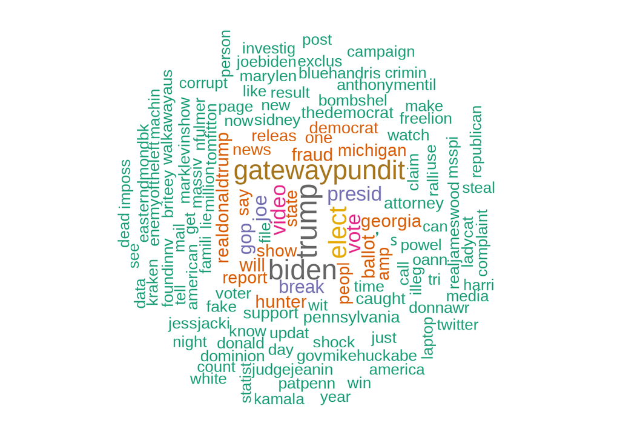

```r
wordcloud(questionable_tweets, min.freq = 5, max.words=120, scale = c(4, 2), random.order=FALSE, rot.per=0.40, colors=brewer.pal(8, "Dark2"))
```

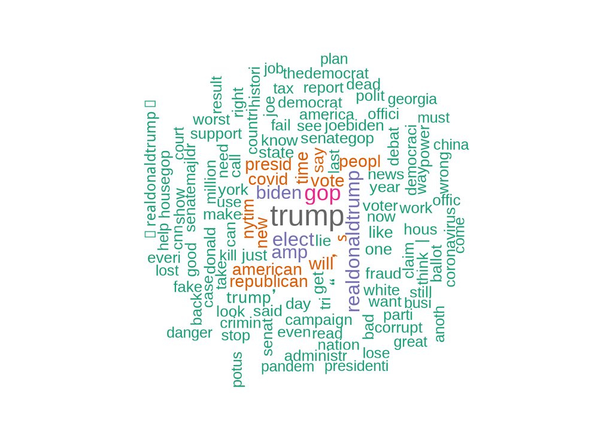

```r
wordcloud(non_questionable_tweets, min.freq = 5, max.words=120, scale = c(4, 2), random.order=FALSE, rot.per=0.40, colors=brewer.pal(8, "Dark2"))
```

As we can see, besides the obvious appearances of terms like *trump*, *realdonaldtrump* (which was the Twitter username for Donald Trump’s official account), *biden*, there are some differences on the terms being used in the questionable and non-questionable tweets.

Let’s plot the term frequency for each of them:

```r
questionable_tweets_dtm <- DocumentTermMatrix(questionable_tweets, control = list(weighting = function(x) weightTfIdf(x, normalize = FALSE), stopwords = TRUE))

non_questionable_tweets_dtm <- DocumentTermMatrix(non_questionable_tweets, control = list(weighting = function(x) weightTfIdf(x, normalize = FALSE), stopwords = TRUE))

plot_frequent_words <- function(dtm) {
  mdf <- as_tibble(as.matrix(dtm))
  mdf.freq <- mdf %>% select(findFreqTerms(dtm,nDocs(dtm)/5)) %>% summarise_all(sum) %>% gather()
  mdf.freq$key <- factor(mdf.freq$key, levels = mdf.freq$key[order(mdf.freq$value)])
  plot <- ggplot(mdf.freq[1:10,] ,aes(x=key,y=value)) + geom_bar(stat="identity") + labs(x="Term",y="Frequency") + coord_flip()
  plot
}
```

Firstly, for the non-questionable tweets:

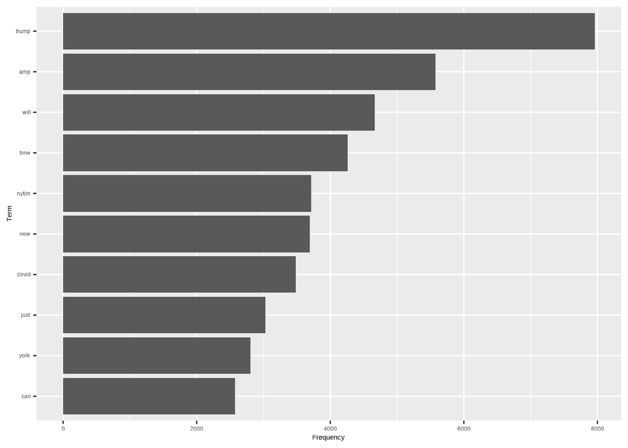

```r
plot_frequent_words(non_questionable_tweets_dtm)
```

And, now, for the questionable tweets:

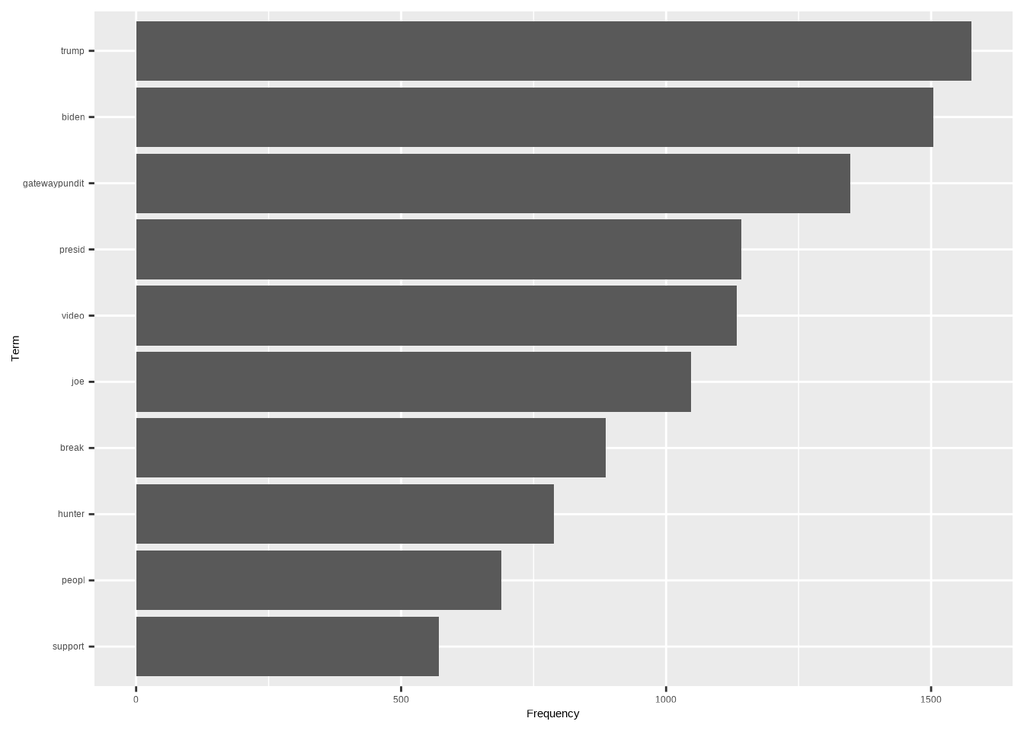

```r
plot_frequent_words(questionable_tweets_dtm)
```

Again, confirming our hypothesis, depending on the type of the tweet, the frequent terms are different, so we can use this information to classify the tweets.

Let’s see how the main candidates, Biden and Trump, are portraied in the questionable and non-questionable tweets:

```r
findAssocs(non_questionable_tweets_dtm, terms = c("trump"), corlimit = 0.1)
```

```
## $trump
##   donald campaign
##     0.19     0.11
```

```r
findAssocs(questionable_tweets_dtm, terms = c("trump"), corlimit = 0.1)
```

```
## $trump
##      presid   nationwid      donald     analysi      switch     support
##        0.37        0.31        0.26        0.25        0.25        0.23
##       tweet        find        eric    blumenth   breitbart      bannon
##        0.20        0.20        0.18        0.18        0.18        0.17
##       steve         sen       delet  zuckerberg         win     gateway
##        0.16        0.16        0.16        0.16        0.15        0.14
##       remov      pundit        mark      awesom         urg        boom
##        0.14        0.13        0.13        0.13        0.13        0.13
##     million        meat       pizza        data      allman        jami
##        0.12        0.12        0.12        0.12        0.12        0.12
##        vote        path      intern       ralli        user       hundr
##        0.11        0.11        0.11        0.11        0.11        0.11
##       corey lewandowski         god     inaugur       swing    facebook
##        0.11        0.11        0.11        0.11        0.10        0.10
##        reed      walter       chant         buy
##        0.10        0.10        0.10        0.10
```

```r
findAssocs(non_questionable_tweets_dtm, terms = c("biden"), corlimit = 0.1)
```

```
## $biden
##              joe httpstcoktcagwrz            enemi        socialist
##             0.35             0.29             0.28             0.27
##           hunter            china         democrat   presidentelect
##             0.22             0.20             0.18             0.15
##              win              won    judicialwatch          victori
##             0.13             0.12             0.12             0.11
##  httpstcojnriiyz       susanlouis          conserv          transit
##             0.11             0.11             0.10             0.10
##            delug
##             0.10
```

```r
findAssocs(questionable_tweets_dtm, terms = c("biden"), corlimit = 0.1)
```

```
## $biden
##              joe           hunter           famili          facetim
##             0.47             0.36             0.23             0.22
##             nake            smoke            crack          yearold
##             0.20             0.20             0.20             0.19
##             text           messag           imposs             girl
##             0.18             0.18             0.18             0.17
##          statist    gatewaypundit         giuliani             rudi
##             0.17             0.16             0.16             0.16
##              boy            email           exclus             talk
##             0.16             0.16             0.16             0.15
##             show           laptop   httpstcossjkib  videotranscript
##             0.13             0.13             0.13             0.13
##         freestyl         guiliani httpstcohvjzuyjf            princ
##             0.13             0.13             0.13             0.13
##            spree      switzerland          pattern           ukrain
##             0.13             0.13             0.13             0.12
##           behind           equiti           former            group
##             0.12             0.12             0.11             0.11
##              lid           spygat            recov            revel
##             0.11             0.11             0.11             0.11
##             flip            split           vacuum            activ
##             0.11             0.11             0.11             0.10
##             read             tape           switch
##             0.10             0.10             0.10
```

As we can see, in the questionable tweets, the terms related to Trump are terms, generally, related to the right-wing world. In the questionable tweets, Biden is related to some controversial terms, but, as far as we known, they are related to his son, Hunter Biden, which we will explore later. In the non-questionable tweets, it’s actually curious to see Biden being associated to terms such as *enemi*, *china* and *socialist*, this really shows the dichotomy of Republicans vs Democrats, in the U.S. elections.

For instance, in the questionable tweets it appears *gatewaypundit* as a frequent word. The Gateway Pundit is an American far-right fake news website.

```r
print(sum(as.integer(str_detect(filter(ds_train, questionable_domain==T)$description, "gatewaypundit"))) / nrow(filter(ds_train, questionable_domain==T)) * 100)
```

```
## [1] 35.68627
```

```r
print(sum(as.integer(str_detect(filter(ds_train, questionable_domain==F)$description, "gatewaypundit"))) / nrow(filter(ds_train, questionable_domain==F)) * 100)
```

```
## [1] 0.02360718
```

Also, in the questionable tweets, it appears frequently the word *hunter*, which, probably, refers to the son of Joe Biden, Hunter Biden, as we said before.

Our first idea was that the content of the tweets were probably related to his, supposedly, controversial life style and business activities, which was a topic, again, recovered with the war in Ukraine.

To confirm our thesis, let’s find the associations with his name, with minimum correlation of 0.25:

```r
findAssocs(questionable_tweets_dtm, terms = c("hunter"), corlimit = 0.25)
```

```
## $hunter
## laptop  biden  email   text   girl  photo   porn vacuum
##   0.55   0.36   0.33   0.30   0.29   0.26   0.25   0.25
```

As we can see, the most associated words to his name (excluding his last name, Biden) are related to the history of his laptop, which allegedly belonged to him and was later recovered, and, with this, a trove of personal emails and photographs found on it, which lead to the various stories stated above. All of this was published less than three weeks before the presidential election, by the New York Post - https://nypost.com/2020/10/14/email-reveals-how-hunter-biden-introduced-ukrainian-biz-man-to-dad.

Since he was the son of one of the candidates to the 2020 presidentials, he was a recurrent topic brought by the Republican Party, the main opposition party. Since none of this is, at least, officially, confirmed, it’s natural that all of this information is classified as questionable.

```r
findAssocs(questionable_tweets_dtm, terms = c("nytim"), corlimit = 0.24)
```

```
## $nytim
## washingtonpost         nbcnew         cnnbrk      hotrodpom     maryltrump
##           0.54           0.43           0.30           0.29           0.29
##   palmerreport    thedailyedg          msnbc projectlincoln       abcpolit
##           0.29           0.29           0.27           0.25           0.25
##         abcnew
##           0.25
```

What we thought that could be interesting to analyse, was the term frequency of these terms in the questionable and in the non-questionable tweets, since, specially during the final stage of the presidentials campaigns, a lot is said about the impartiality of these news programs.

Let’s then plot the distribution of these terms regarding the questionability of the tweet:

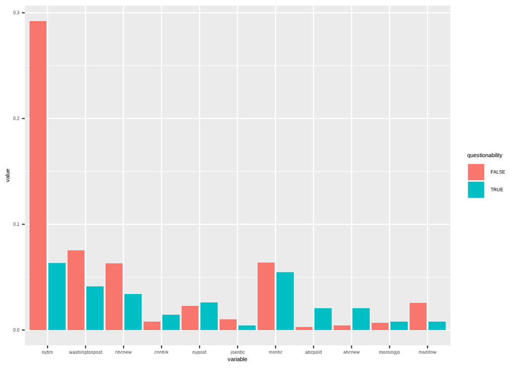

```r
midia <- c("nytim", "washingtonpost", "nbcnew", "cnnbrk", "nypost", "joenbc", "msnbc", "abcpolit", "abcnew", "morningjo", "maddow")

midia_non_quest <- as_tibble(as.matrix(non_questionable_tweets_dtm)[,midia][,1:length(midia)])
midia_non_quest <- mutate(midia_non_quest, questionable_domain=as.factor("FALSE"))

midia_quest <- as_tibble(as.matrix(questionable_tweets_dtm)[,midia][,1:length(midia)])
midia_quest <- mutate(midia_quest, questionable_domain=as.factor("TRUE"))

midia_data <- rbind(midia_non_quest, midia_quest)

gg <- melt(midia_data, id="questionable_domain")
colnames(gg) <- c("questionability", "variable", "value")
ggplot(gg, aes(x=variable, y=value, fill=questionability)) +
    stat_summary(fun.y=mean, geom="bar",position=position_dodge(1)) +
    scale_color_discrete("questionability")
```

Sadly, only the *nytim* term seems to have a significant difference regarding the type of the tweet. We inspected the tweets that contain the term and it seems to be mostly citations of the news.

Also, we would need major care to conclude something if a different distribution regarding the tweets appeared, since the questionability of the tweets containing any of these newspaper can be due to wrong citations and/or false accusations, which, with a analysis only from the distribution regarding both set of tweets, would influence the agency negatively, but, in reality, it’s nothing related to the agency itself.

```r
TfIdfVetorizer <- function(ds) {
  tweets <- Corpus(VectorSource(ds$description))
  tweets <- cleanup(tweets)
  dtm <- DocumentTermMatrix(tweets, control = list(weighting = function(x) weightTfIdf(x, normalize = T)))

  ds <- cbind(ds, as.matrix(dtm)[, c("trump", "amp", "time", "nytim", "presid", "covid",
                                     "gatewaypundit", "biden", "video", "hunter", "will")])
  ds
}

ds_train <- TfIdfVetorizer(ds_train)
ds_test <- TfIdfVetorizer(ds_test)
```

For instance, the first 15 observations for the new attribute *trump*:

```r
ds_train$trump[1:15]
```

```
##  [1] 0.00000000 0.00000000 0.00000000 0.00000000 0.00000000 0.06956521
##  [7] 0.05746691 0.00000000 0.06956521 0.00000000 0.00000000 0.00000000
## [13] 0.08811593 0.08811593 0.08811593
```

Let’s now do a emotion and sentiment analysis:

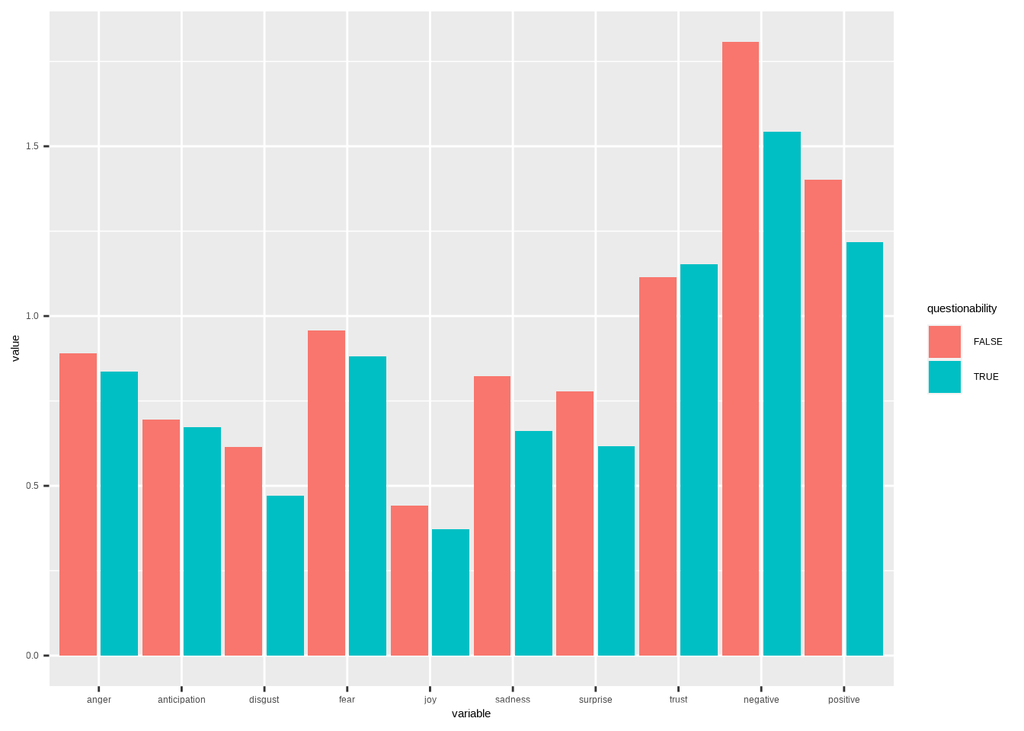

```r
emotions <- c("anger", "anticipation", "disgust", "fear", "joy", "sadness", "surprise", "trust", "negative", "positive")

nrc_data_train <- get_nrc_sentiment(ds_train$description)
nrc_data_test <- get_nrc_sentiment(ds_test$description)

gg <- melt(cbind(nrc_data_train[,1:10], ds_train$questionable_domain), id="ds_train$questionable_domain")   # df is your original table
colnames(gg) <- c("questionability", "variable", "value")
ggplot(gg, aes(x=variable, y=value, fill=questionability)) +
  stat_summary(fun.y=mean, geom="bar",position=position_dodge(1)) +
  scale_color_discrete("questionability") #+ stat_summary(fun.ymin=min,fun.ymax=max,geom="errorbar", color="grey80",position=position_dodge(1), width=.2)
```

Sadly, we see the same distribution for the positive or negative valence and for the emotions, in both set of tweets.

This is quite intuitive, because it’s easy to imagine that a user can have both positive and negative sentiments and emotions writing a tweet that is questionable or not.

Let’s do a summary for the non-questionable tweets:

```r
id_nrc_data_train <- cbind(id=ds_train$id, nrc_data_train)
id_nrc_data_test <- cbind(id=ds_test$id, nrc_data_test)

nrc_data_non_quest <- filter(id_nrc_data_train, id %in% filter(ds_train, questionable_domain==F)$id)

lapply(nrc_data_non_quest[,-1], summary)
```

```
## $anger
##    Min. 1st Qu.  Median    Mean 3rd Qu.    Max.
##  0.0000  0.0000  1.0000  0.8903  1.0000  7.0000
##
## $anticipation
##    Min. 1st Qu.  Median    Mean 3rd Qu.    Max.
##  0.0000  0.0000  0.0000  0.6944  1.0000  6.0000
##
## $disgust
##    Min. 1st Qu.  Median    Mean 3rd Qu.    Max.
##   0.000   0.000   0.000   0.615   1.000   8.000
##
## $fear
##    Min. 1st Qu.  Median    Mean 3rd Qu.    Max.
##  0.0000  0.0000  1.0000  0.9572  2.0000  8.0000
##
## $joy
##    Min. 1st Qu.  Median    Mean 3rd Qu.    Max.
##  0.0000  0.0000  0.0000  0.4408  1.0000  6.0000
##
## $sadness
##    Min. 1st Qu.  Median    Mean 3rd Qu.    Max.
##  0.0000  0.0000  1.0000  0.8224  1.0000  7.0000
##
## $surprise
##    Min. 1st Qu.  Median    Mean 3rd Qu.    Max.
##  0.0000  0.0000  1.0000  0.7774  1.0000  5.0000
##
## $trust
##    Min. 1st Qu.  Median    Mean 3rd Qu.    Max.
##   0.000   0.000   1.000   1.114   2.000   8.000
##
## $negative
##    Min. 1st Qu.  Median    Mean 3rd Qu.    Max.
##   0.000   1.000   2.000   1.808   3.000  12.000
##
## $positive
##    Min. 1st Qu.  Median    Mean 3rd Qu.    Max.
##   0.000   0.000   1.000   1.402   2.000  11.000
```

Now for the questionable tweets:

```r
nrc_data_quest <- filter(id_nrc_data_train, id %in% filter(ds_train, questionable_domain==T)$id)

lapply(nrc_data_quest[,-1], summary)
```

```
## $anger
##    Min. 1st Qu.  Median    Mean 3rd Qu.    Max.
##  0.0000  0.0000  1.0000  0.8365  1.0000  6.0000
##
## $anticipation
##    Min. 1st Qu.  Median    Mean 3rd Qu.    Max.
##  0.0000  0.0000  0.0000  0.6737  1.0000  5.0000
##
## $disgust
##    Min. 1st Qu.  Median    Mean 3rd Qu.    Max.
##   0.000   0.000   0.000   0.471   1.000   6.000
##
## $fear
##    Min. 1st Qu.  Median    Mean 3rd Qu.    Max.
##  0.0000  0.0000  1.0000  0.8816  1.0000  5.0000
##
## $joy
##    Min. 1st Qu.  Median    Mean 3rd Qu.    Max.
##  0.0000  0.0000  0.0000  0.3729  1.0000  5.0000
##
## $sadness
##    Min. 1st Qu.  Median    Mean 3rd Qu.    Max.
##   0.000   0.000   0.000   0.662   1.000   4.000
##
## $surprise
##    Min. 1st Qu.  Median    Mean 3rd Qu.    Max.
##  0.0000  0.0000  0.0000  0.6165  1.0000  5.0000
##
## $trust
##    Min. 1st Qu.  Median    Mean 3rd Qu.    Max.
##   0.000   0.000   1.000   1.153   2.000   7.000
##
## $negative
##    Min. 1st Qu.  Median    Mean 3rd Qu.    Max.
##   0.000   0.000   1.000   1.544   2.000   9.000
##
## $positive
##    Min. 1st Qu.  Median    Mean 3rd Qu.    Max.
##   0.000   0.000   1.000   1.218   2.000   7.000
```

```r
ds_train$extreme_emotion = 0
for (i in 1:nrow(ds_train)) {
  if(any(nrc_data_train[i,] > 5)) {
    ds_train$extreme_emotion[i] = 1
  }
}

ds_test$extreme_emotion = 0
for (i in 1:nrow(ds_test)) {
  if(any(nrc_data_test[i,] > 5)) {
    ds_test$extreme_emotion[i] = 1
  }
}
```

If we had time stamps from when the tweet was posted, we could also see how all of this changed over time. We could even try to see the changes in the public opinion, in the face of dramatic events, such as when the history involving Hunter Biden’s laptop went public.

Also, we will look into the emotional ambiguity, i.e., the conflicting valence found in the tweet. Emotional entropy can be thought of as a measure of unpredictability and surprise based on the consistency or inconsistency of the emotional language in a given message. We expect this to be important, since questionable tweets tend to be unpredictable and sometimes even contradictory:

```r
ds_train_tweets_mixed_messages <- lapply(ds_train$description, mixed_messages)
ds_train_tweets_mixed_messages <- do.call(rbind, ds_train_tweets_mixed_messages)

ds_test_tweets_mixed_messages <- lapply(ds_test$description, mixed_messages)
ds_test_tweets_mixed_messages <- do.call(rbind, ds_test_tweets_mixed_messages)
```

```r
gg <- melt(cbind(tibble(metric_entropy=ds_train_tweets_mixed_messages[,2]), ds_train$questionable_domain))
```

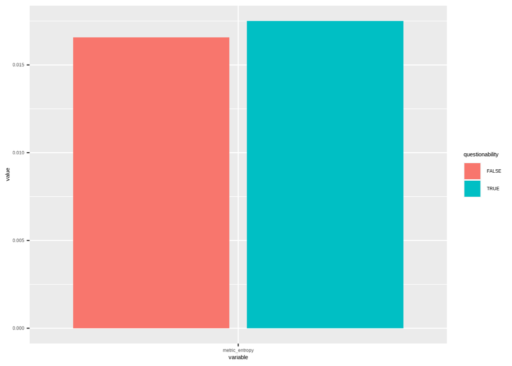

```r
colnames(gg) <- c("questionability", "variable", "value")
ggplot(gg, aes(x=variable, y=value, fill=questionability)) +
  stat_summary(fun.y=mean, geom="bar",position=position_dodge(1)) + scale_color_discrete("questionability")
```

Surprisingly, we see a evenly distributed metric entropy between the two sets of tweets.

In any case, we will add a new column **metric_entropy**, containing the metric entropy of the tweet, for the reasons stated before and we saw that it is useful through some experimental tests:

```r
ds_train <- cbind(ds_train, metric_entropy=ds_train_tweets_mixed_messages[,2])
ds_test <- cbind(ds_test, metric_entropy=ds_test_tweets_mixed_messages[,2])
```

Finally, we can remove the **description** attribute:

```r
ds_train <- select(ds_train, -description)
ds_test <- select(ds_test, -description)
```

A view of the final, improved, data set:

```r
glimpse(ds_train)
```

```
## Rows: 15,258
## Columns: 21
## $ id                  <dbl> 1.310325e+18, 1.310896e+18, 1.311657e+18, 1.312330…
## $ questionable_domain <fct> FALSE, TRUE, FALSE, FALSE, FALSE, FALSE, FALSE, FA…
## $ PC1                 <dbl> 0.11938314, -0.21297163, 0.18263218, 0.17114684, 0…
## $ PC2                 <dbl> -0.27930081, -0.98397324, 0.45801448, 0.41878310, …
## $ PC3                 <dbl> -0.0307518409, -0.1192703795, 0.1400080183, 0.1253…
## $ PC4                 <dbl> -0.2941005, -0.2669461, -0.3361615, -0.3297437, -0…
## $ PC5                 <dbl> -0.23902869, -0.55379163, -0.16310786, -0.16386266…
## $ PC6                 <dbl> -0.03835782, -0.62111417, 0.26343181, 0.26404552, …
## $ trump               <dbl> 0.00000000, 0.00000000, 0.00000000, 0.00000000, 0.…
## $ amp                 <dbl> 0.1502787, 0.0000000, 0.0000000, 0.0000000, 0.0000…
## $ time                <dbl> 0.0000000, 0.0000000, 0.0000000, 0.0000000, 0.0000…
## $ nytim               <dbl> 0.000000, 0.000000, 1.945827, 0.000000, 0.000000, …
## $ presid              <dbl> 0.0000000, 0.0000000, 0.0000000, 0.0000000, 0.0000…
## $ covid               <dbl> 0.0000000, 0.0000000, 0.0000000, 0.0000000, 0.0000…
## $ gatewaypundit       <dbl> 0.0000000, 0.0000000, 0.0000000, 0.0000000, 0.0000…
## $ biden               <dbl> 0.0000000, 0.0000000, 0.0000000, 0.0000000, 0.0000…
## $ video               <dbl> 0.0000000, 0.0000000, 0.0000000, 0.0000000, 0.0000…
## $ hunter              <dbl> 0.0000000, 0.0000000, 0.0000000, 0.0000000, 0.0000…
## $ will                <dbl> 0.1477578, 0.0000000, 0.0000000, 0.0000000, 0.0000…
## $ extreme_emotion     <dbl> 0, 0, 1, 0, 0, 0, 0, 0, 0, 0, 0, 0, 0, 0, 0, 0, 0,…
## $ metric_entropy      <dbl> 0.02662779, 0.00000000, 0.01569409, 0.02782715, 0.…
```

Let’s train our models, again, but now with the improvements done:

```r
x_train = select(ds_train, -c(id, questionable_domain))
y_train <- ds_train$questionable_domain
x_test = select(ds_test, -c(id, questionable_domain))
y_test = ds_test$questionable_domain

improved.results <- fit(x_train, y_train, x_test, y_test)
```

```r
improved.results
```

```
##                  Accuracy Precision    Recall        F1
## kNN             0.8569837 0.8763681 0.9643176 0.9182417
## Naive Bayes     0.7979198 0.8637532 0.8991971 0.8811189
## XGBoost         0.8993314 0.8946736 0.9964318 0.9428149
## Random Forests  0.8919019 0.8941414 0.9870651 0.9383082
## Neural Networks 0.8209510 0.8897254 0.8960749 0.8928889
```

We even tried to balance our data set, by doing both under-sampling and over-sampling:

```r
balanced.ds <- SMOTE(questionable_domain ~ .,
                     data = as.data.frame(select(ds_train, -id)),
                     perc.over = 100,
                     k = 11,
                     perc.under = 200)
```

Let’s test it:

```r
x_train <- select(balanced.ds, -c(questionable_domain))
y_train <- balanced.ds$questionable_domain
x_test <- select(ds_test, -c(questionable_domain))
y_test <- ds_test$questionable_domain

balanced.results <- fit(x_train, y_train, x_test, y_test)
```

```r
balanced.results
```

```
##                  Accuracy Precision    Recall        F1
## kNN             0.4858841 0.9093511 0.4250669 0.5793313
## Naive Bayes     0.8811293 0.8844000 0.9861731 0.9325179
## XGBoost         0.7652303 0.9102956 0.7966102 0.8496670
## Random Forests  0.6953938 0.9232143 0.6917930 0.7909230
## Neural Networks 0.4153046 0.9083130 0.3314005 0.4856209
```

As we can see, we got worse results. This is because SMOTE does linear interpolation of the data and since we mainly working with features extracted from text, linear interpolation becomes meaningless.

We also tried to just do under-sampling of the majority class, but still, we got worse results for every model:

```r
balanced.ds <- rbind(filter(ds_train, questionable_domain==T), filter(ds_train, questionable_domain==F)[1:nrow(filter(ds_train, questionable_domain==T)),])
balanced.ds <- slice(balanced.ds, sample(1:n()))

x_train <- select(balanced.ds, -c(id, questionable_domain))
y_train <- balanced.ds$questionable_domain
x_test <- select(ds_test, -c(id, questionable_domain))
y_test <- ds_test$questionable_domain

balanced.results <- fit(x_train, y_train, x_test, y_test)
```

```r
balanced.results
```

```
##                  Accuracy Precision    Recall        F1
## kNN             0.3837296 0.8923284 0.2957181 0.4442211
## Naive Bayes     0.4836553 0.9034091 0.4255129 0.5785324
## XGBoost         0.7269688 0.9207147 0.7355040 0.8177535
## Random Forests  0.7306835 0.9142545 0.7466548 0.8219985
## Neural Networks 0.5401189 0.9254237 0.4870651 0.6382233
```

So, overall, our best model was a XGBoost model.

Let’s do a final predict on the unseen data and check the results:

```r
x_train = select(ds_train, -c(id, questionable_domain))
y_train <- ds_train$questionable_domain
x_test = select(ds_test, -c(id, questionable_domain))
y_test = ds_test$questionable_domain

xgb_model = train(x = x_train,
                      y = y_train,
                      trControl = trainControl(method  = "cv", number  = 10, classProbs = F),
                      method = "xgbTree",
                      tuneGrid = expand.grid(nrounds = c(50,100,150,200), max_depth = c(2,5), eta = 0.05, gamma = 0.01,
                                      colsample_bytree = c(0.3,0.7), min_child_weight=0, subsample = 0.7),
                      verbosity = 0)

xgb_results <- predict(xgb_model, x_test)
xgb_conf <- confusionMatrix(xgb_results, y_test)
xgb_conf
```

```
## Confusion Matrix and Statistics
##
##           Reference
## Prediction FALSE TRUE
##      FALSE  2237  263
##      TRUE      5  187
##
##                Accuracy : 0.9004
##                  95% CI : (0.8885, 0.9115)
##     No Information Rate : 0.8328
##     P-Value [Acc > NIR] : < 2.2e-16
##
##                   Kappa : 0.5362
##
##  Mcnemar's Test P-Value : < 2.2e-16
##
##             Sensitivity : 0.9978
##             Specificity : 0.4156
##          Pos Pred Value : 0.8948
##          Neg Pred Value : 0.9740
##              Prevalence : 0.8328
##          Detection Rate : 0.8310
##    Detection Prevalence : 0.9287
##       Balanced Accuracy : 0.7067
##
##        'Positive' Class : FALSE
##
```

We got, relatively, good results, but our model still struggles identifying questionable tweets.

Let’s see the variable importance:

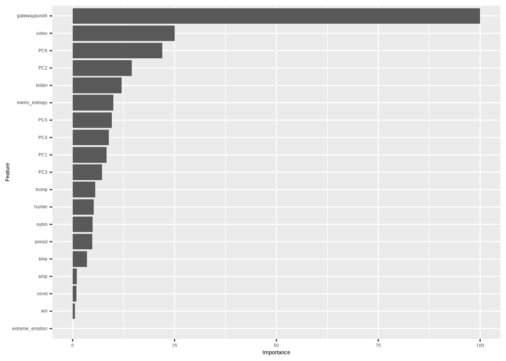

```r
ggplot(varImp(xgb_model))
```

## Conclusion

The biggest challenge was in the data pre-processing and feature engineering part, specially, dealing with the tweet’s content - the attribute **description**. The reality is that it is not trivial to classify some information as questionable or not. For a particular and reduced data set, a simple syntactic and/or semantic analysis may provide good results, but, overall, it would requires us to process the statement being said and factually check it, against a knowledge base. For this particular problem, future work could pass from gathering new features, incorporating the time stamps of the tweets and gather even more data, in order to improve our classifications models. With a good model, Twitter could use this in order to stop, or, at least, reduce, the spread of misinformation. In fact, it would be interesting to test this model in the 2024 upcoming elections, since it’s expected to be, again, a race between Biden and Trump.